# Analysing interactions between beet’s rootsystem and nematodes

Artur Freeman & Tom Kenda

mai 10, 2022,00:47

# 1 : SET UP

*When using CRootBox for the first time you should also run this :*

The code should compile with any c++11 compiler, e.g. for g++: MinGW has been tested. Then create a new system environment variable. Path –> `C:\MinGW\bin`

```r
# Open the terminal:
#   cd ~/GitHub/marshal-pipeline/17_06 CRootBox
#
# FOR MAC AND LINUX
# g++ *.cpp -std=c++11 -o crootbox.out
# crootbox.out
#
#
# FOR WINDOWS
# g++ *.cpp -std=c++11 -o crootbox.exe
# crootbox.exe


# Custom functions
# source("inputs/io_function.R") # CROOTBOX

# Update the crootbox executable file
# MAC
# file.copy("inputs/crootbox_source/crootbox.out",
#           "inputs/crootbox.out",
#           overwrite = T)
# WINDOWS
# file.copy("inputs/crootbox_source/crootbox.exe",
#           "inputs/crootbox.exe",
#           overwrite = T)
```

# 2 : SET THE SIMULATION PARAMETERS & RUN CROOTBOX

Note : a detailled list of the parameters can be found in the following article (namely in table 2 and 3 )

[output not shown]

Some parameters were found using the SmaartRoot software (integrated in ImageJ, see source below) combined with beet root scans. For some other parameter we could not find any information in the litterature and thus we had to set them arbitrarly.

```
*A Novel Image Analysis Toolbox Enabling Quantitative Analysis of Root System Architecture. Guillaume Lobet, Loic Pages and Xavier Draye, 2011*
```

```r
# CROOTBOX PARAMETERS

### A. We load the default parameter sets for the simulation
rparam <- read_rparam(path = "inputs/param_default.rparam")
pparam <- read_pparam(path = "inputs/param_default.pparam")

### B. Define the parameter

## B.1. We store the input parameters into 'easy-to-understand' variables

# - - - - - - - - - - - ### unit   ### source

## Plant param
simulation_time <- 200  # [days]
planting_depth <- 3     # [cm]  (Romaneckas et al., 2009)
maxB <- 0               # [1]   (Weaver and Bruner, 1927) no basal root for beet

## Root param     nb: a=radius, vitesseP=initial elong. rate
# Type 1 : Pivot
a_1 <- 0.129              # [cm]      littérature https://doi.org/10.3390/agriculture11010021
vitesseP_1 <- 1.7621349   #[cm/jour] < smartroot
lb_1 <- 2                 # [cm]      < arbitraire
la_1 <- 12                # [cm]      < arbitraire
ln_1<- 1.6031327          # [cm]      < Smartroot
lmax_1 <- 300             # [cm]      littérature https://doi.org/10.1080/14620316.2006.11512146
succ_val1_1 <- 2          # Nombre de successeurs sur taproot
succ_val2_1 <- 2          # Type du successeur 1
succ_val3_1 <- 3          # Type du successeur 2
succP_val1_1 <- 2         # Nombre de successeurs sur taproot = succ_val1_1
succP_val2_1 <- 0.33      # probability  (Weaver and Bruner, 1927)
succP_val3_1 <- 0.66      # probability  (Weaver and Bruner, 1927)

# à vérifié !! --> (Weaver and Bruner, 1927)
# inversé long lateral et latéral normal ? car taille pas logique ?


# TYPE 2: Lateral (short)
a_2 <- 0.10               # [cm]      (Weaver and Bruner, 1927)
vitesseP_2 <- 0.3802029   # [cm/jour] < Smartroot
lmax_2 <- 7.0             # [cm]      (Weaver and Bruner, 1927)
sigma_tropism_2 <- 0.2    # ?? !!!!


# TYPE 3 : Longue lateral
a_3 <- 0.10               # [cm]      (Weaver and Bruner, 1927)
vitesseP_3 <- 0.75        # [cm/jour] < Smartroot
lmax_3 <- 240             # [cm]      (Weaver and Bruner, 1927)
sigma_tropism_3 <- 0.2


#### B.2. we store all parameter in the rparam and pparam file

launch_simulation <- function(simulation_time=20){
  ## function to launch the simulation :
  ## 1. store parameter defined in the global env. in the P and R param file
  ## 2. run CRootBox
  ## 3. return the current rootsystem as a dataframe

 # Global parameters - PParam
 pparam$val1[pparam$param == "simtime"] <- simulation_time
 pparam$val1[pparam$param == "plantingdepth"] <- planting_depth
 pparam$val1[pparam$param == "maxB"] <- maxB

 # Type 1 : Pivot
 rparam$val1[rparam$name == "Taproot" & rparam$param == "a"] <-   a_1
 rparam$val1[rparam$name == "Taproot" & rparam$param == "r"] <-   vitesseP_1
 rparam$val1[rparam$name == "Taproot" & rparam$param == "lb"] <-  lb_1
 rparam$val1[rparam$name == "Taproot" & rparam$param == "la"] <-  la_1
 rparam$val1[rparam$name == "Taproot" & rparam$param == "lmax"]<- lmax_1
 rparam$val1[rparam$name == "Taproot" & rparam$param == "ln"] <-  ln_1

 rparam$val1[rparam$name == "Taproot" & rparam$param == "successors"] <- succ_val1_1
 rparam$val2[rparam$name == "Taproot" & rparam$param == "successors"] <- succ_val2_1
 rparam$val3[rparam$name == "Taproot" & rparam$param == "successors"] <- succ_val3_1
 rparam$val1[rparam$name == "Taproot" & rparam$param == "successorP"] <- succP_val1_1
 rparam$val2[rparam$name == "Taproot" & rparam$param == "successorP"] <- succP_val2_1
 rparam$val3[rparam$name == "Taproot" & rparam$param == "successorP"] <- succP_val3_1

 #TYPE 2: Lateral
 rparam$val1[rparam$name == "Lateral" & rparam$param == "a"] <-   a_2
 rparam$val1[rparam$name == "Lateral" & rparam$param == "r"] <-   vitesseP_2
 rparam$val1[rparam$name == "Lateral" & rparam$param == "lmax"] <- lmax_2

 #TYPE 3 : Longue lateral
 rparam$val1[rparam$name == "LongLateral" & rparam$param == "a"] <-   a_3
 rparam$val1[rparam$name == "LongLateral" & rparam$param == "r"] <-   vitesseP_3
 rparam$val1[rparam$name == "LongLateral" & rparam$param == "lmax"] <- lmax_3

 # update the input text files
 write_rparam(rparam, "inputs/param.rparam")
 write_pparam(pparam, "inputs/param.pparam")

 ### Run crootbox ###
 system("inputs/crootbox.exe") # Run crootbox for windows

 # Load the simulated data into R to process it and to store it for further use
 current_rootsystem <- fread("outputs/current_rootsystem.txt", header = T)

 return(current_rootsystem)
}

# C. We create variables that will contain the
# results of our crootbox simulations
all_rootsystems <- NULL
all_totlength <- NULL
n_tot_simulation <- 1
n_cr_sim <- 0

current_rootsystem <- launch_simulation(simulation_time = 200)
```

# 3 : EXTRACT DATA FROM ROOTSYSTEM

This part is useful only if we loop and create many root system - see later (section 8)

```r
# We enrich the root system simulation data with metadata
# This is needed to find back the information in the large data file
# at the end of the simulations
current_rootsystem <- current_rootsystem %>%
                      mutate(vitesse_primaire = vitesseP_1,
                             vitesse_secondaire = vitesseP_2,
                             densite_lat = ln_1,
                             simulation_id = n_cr_sim)

# We create a table with all the root systems
all_rootsystems <- rbind(all_rootsystems, current_rootsystem)

# We store the root system simulation with a unique name
write_csv(current_rootsystem,
          paste0("outputs/rootsystems/rootsystem_",vitesseP_1,
                 "_",vitesseP_2,
                 "_",ln_1,
                 ".csv"))

# OPTIONAL
# extract the root length density from the simulation data
# The idead here is, if needed, to store only the relevant info
# out of our simulation run and discard the rest

totlength <- data.frame(vitesse_primaire = vitesseP_1,
                        vitesse_secondaire = vitesseP_2,
                        densite_lateral = ln_1,
                        simulation_id = n_cr_sim,
                        total_length = sum(current_rootsystem$length),
                        n_root = length(unique(current_rootsystem$branchID)))

# We store in a data frame the rld from all the simulations
all_totlength <- rbind(all_totlength, totlength)
```

# 4 : PLOT THE ROOT SYSTEM

```r
# Root system from the side
plot_current_root_S <- function(current_rootsystem){
  # cat("Plot of the root system from the side ")
  current_rootsystem %>%
    ggplot() +
    theme_classic() +
    geom_segment(aes(x = x1, y = z1, xend = x2, yend = z2, colour=time),
                 alpha=0.9)+
    scale_colour_gradientn(colours = terrain.colors(10)) +
    coord_fixed()
}

# Root system from above
cat("Plot of the root system from below/above")
```

```
Plot of the root system from below/above
```

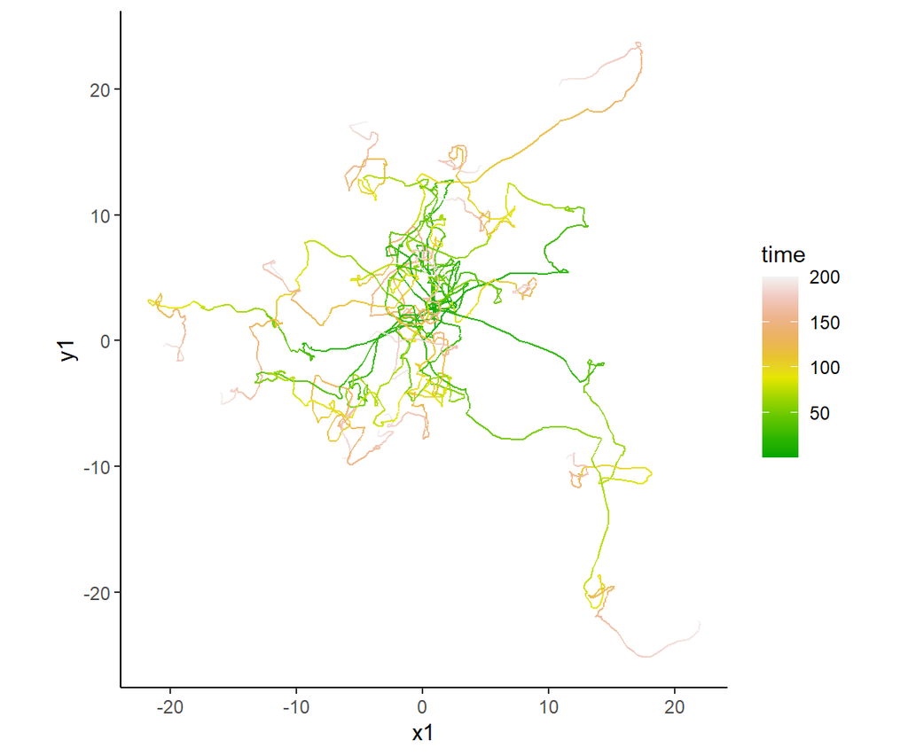

```r
current_rootsystem %>%
  ggplot() +
  theme_classic() +
  geom_segment(aes(x = x1, y = y1, xend = x2, yend = y2, colour = time), alpha=0.9) +
  scale_colour_gradientn(colours = terrain.colors(10)) +
  coord_fixed()
```

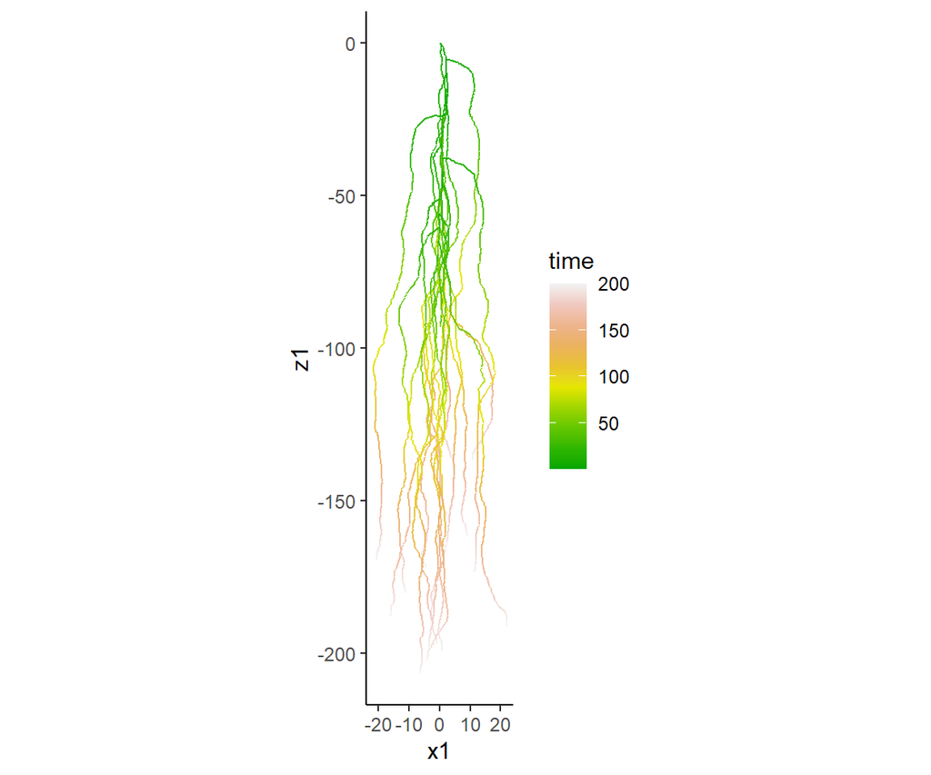

```r
plot_current_root_S(current_rootsystem)
```

# 5 : Get the root volume for each time step and each soil layer

We created 2 functions here : the first one to extract the root volume (RV) in each layer of soil and the second one to plot it. This will be used to model the nematode population later on.

```r
root_volume <- function(current_rootsystem, max_depth=300, layer_width=50, round=4){
  # function that take root system as a dataframe (containing at least the time, volume,
  # length and depth (z2) of each root segment) then compute the lateral root volume for
  # each soil layer from 0 cm to max_depth (cm) with a layer width of 'layer_width'

  # calculate the volume of each root segment (assuming this is cylinder pi * r² * l) in cm³ ?
  current_rootsystem$volume <- pi * current_rootsystem$radius**2 * current_rootsystem$length

  # Get a vector with the depth of the layers
  d <- 0
  depth_list <- NULL
  while(d > -max_depth){
    depth_list <- c( depth_list, d )
    d <- d - layer_width
  }
  #cat("\n depth_list : ", depth_list)

  # initialize the dataframe to store result of RV
  simulation_time <- max(current_rootsystem$time)
  RV <- setNames(data.frame(matrix(ncol = length(depth_list), nrow = simulation_time)), depth_list)

  # loop over time and depth

  for(ti in 1:nrow( RV )) {      # for timestep i
    rootsystem_Ti <- current_rootsystem[ current_rootsystem$time <= ti ]

    for(depth in depth_list) {    # for depth i
      rootsystem_Ti_Di <- rootsystem_Ti[ rootsystem_Ti$z2 > (depth - layer_width) & rootsystem_Ti$z2 <= depth ]

      RV[ti, toString(depth)] <- round(sum(rootsystem_Ti_Di$volume), round)

    }
  }
  # return the dataframe with the RV
  RV
}

# test
RV <- root_volume(current_rootsystem, 100, 20)
RV
```

```
         0    -20    -40    -60    -80
1   0.2825 0.0000 0.0000 0.0000 0.0000
2   0.5254 0.0000 0.0000 0.0000 0.0000
3   0.6354 0.1451 0.0000 0.0000 0.0000
4   0.6501 0.3436 0.0000 0.0000 0.0000
5   0.6720 0.5277 0.0000 0.0000 0.0000
6   0.6941 0.5946 0.1066 0.0000 0.0000
7   0.7117 0.6073 0.2691 0.0000 0.0000
8   0.7361 0.6232 0.4085 0.0000 0.0000
9   0.7481 0.6491 0.5180 0.0000 0.0000
10  0.7641 0.6853 0.6093 0.0150 0.0000
11  0.7760 0.7142 0.6149 0.1040 0.0000
12  0.7924 0.7459 0.6233 0.2145 0.0000
13  0.8040 0.7742 0.6352 0.2850 0.0000
14  0.8201 0.8119 0.6461 0.3444 0.0000
```

[output cut: 186 more lines]

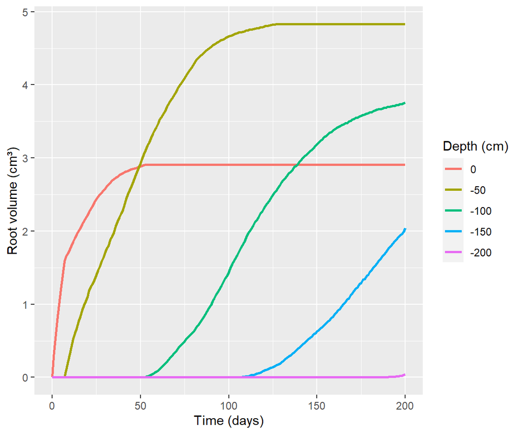

```r
plot_RV <- function(RV, line_width=1){
  # function that plot the lateral root volume for each soil layer
  # input : RV , a df containing one colunm for each soil layer
  # output : ggplot graph

  # add a vector time to reshape/melt the DF
  time <- data.frame("time"= c(0:nrow(RV)))
  RV <- rbind(c(0), RV) # just add the (0,0) to each layer
  RV_time <- cbind(time, RV)
  # melt in 3 columns
  RV_long <- melt(RV_time, id="time", variable.name = "depth" )

  # plot
  RV_plot <- ggplot(RV_long,
                     aes(x = time,
                         y = value,
                         color = depth)) +  geom_line(size=line_width) +
    labs(y="Root volume (cm³)", x="Time (days)", color="Depth (cm)")

  # return the plot
  RV_plot
}

# testing the 2 functions :
RV <- root_volume(current_rootsystem, 250, 50)
plot_RV(RV)
```

# 6. Build the model for nematode development

## Modeling soil temperature

We determined an equation to simulate the soil temperature at different depths for different soil types (described in ‘temperature model.pdf’). This temperature is a key parameter for the development of nematodes in the soil.

```r
# optimum parameters of the thermal wave :
# beta1: average, beta2: amplitude, beta3: phase shift
beta_opti <- c(10.26, 7.238, -1.973)

#alpha <- 0.015 # thermal diffusivity of the soil, here wet clay

soiltemp <- function(depth, alpha, timerange, beta_opti = beta_opti) {
  beta_opti[1] +
    beta_opti[2] *
        (exp(-depth*sqrt(pi/(alpha*365)))) *
        cos( (((2*pi*timerange)/365)) - depth*sqrt(pi/((alpha)*365)) - beta_opti[3] )
}
```

## Modelling nematod polulation according to soil t° and root volume

I put together the 2 bocs of the model: the soil temperature model, and the model that takes this development cycle to model the interaction of the nematodes.

If the temperatures are below the development threshold (here 11°C), the model considers that the population does not develop and therefore remains constant. If temperatures are above the threshold, the population starts to grow.

**test avec un sol argileux humide à 10cm de profondeur**

### Logistic function

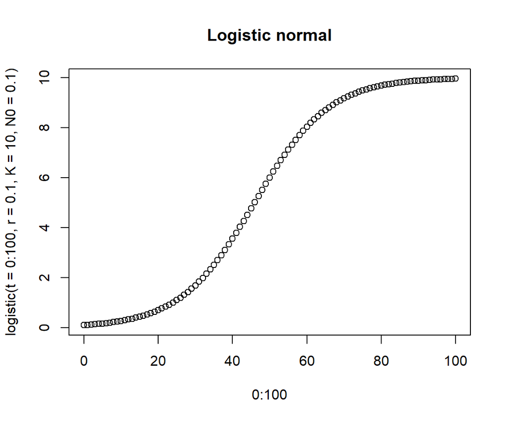

```r
logistic <- function(t, r, K, N0) {
  K * N0 * exp(r * t) / (K + N0 * (exp(r * t) - 1))
}

plot(0:100, logistic(t=0:100, r=0.1, K=10, N0=0.1), main='Logistic normal')
```

### r-Factor function

The relationship between growth rate and temperature is approximately linear. (source : https://www.ncbi.nlm.nih.gov/pmc/articles/PMC4755701/)

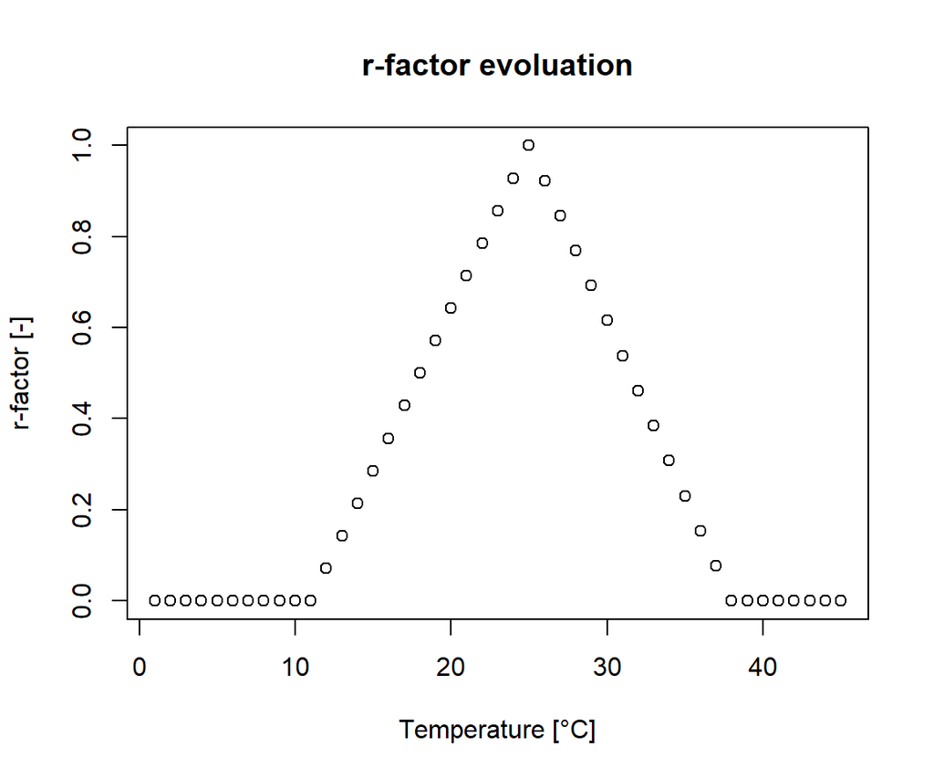

```r
getRFactor <-function(Temperature, TempOpti=25, TempSEuil=11,TempMax=38 ){
  #tempseuil : 11°C pour Heterodera Schachtii
  #tempOpt : 25 °C environ
  #tempMax : 38°C environ.

  if(Temperature < TempOpti && Temperature >= TempSEuil){
    r_factor <- (Temperature - TempSEuil) / (TempOpti - TempSEuil)
  }

  else if (Temperature >=TempOpti && Temperature <= TempMax) {
    r_factor <- 1-((Temperature-TempOpti)/(TempMax-TempOpti))
  }
  else {r_factor <- 0}

  return(r_factor)
}

# test & visualize
t <- c(1:45)
r_factor <- t*0
for(i in t){
  r_factor[i] <- getRFactor(i)
}
plot(t, r_factor, main="r-factor evoluation", ylab = "r-factor [-]", xlab = "Temperature [°C]" )
```

### Model function

```r
modele <- function(depth_m, alpha, planting_day, seuil,  Pop_init, RV_layer_i,
                   K_pot, r_max=0.07) {
  ## SPEC. : depth  should be given in absolute value and in meters

  ## r_max <- 0.07 approximately the maximum growing rate for a population ~ the max
  ## slope of the curve according to in situ data
  ##  r = r_max * r_factor and r_factor = 1 when temp° is optimal

  time_range <- c(planting_day:(planting_day+nrow(RV_layer_i)-1))

  pop <- rep(Pop_init,length(time_range))

  tempSim <- soiltemp(depth_m, alpha, time_range, beta_opti)

  K <- RV_layer_i * K_pot

  for (i in c(2:(length(time_range))) ){

    if (tempSim[i]> seuil && K[i,] > 0) {

      ri <- r_max * getRFactor(tempSim[i])

      pop[i] <- logistic(1 , r = ri, K = K[i,], N0 = pop[i-1] )
    }
    else {pop[i] = pop[i-1]}
  }
  return(pop)
}

modele(depth_m = 0.1, alpha = 0.015, planting_day = 90, seuil = 11, Pop_init = 10,
      RV_layer_i = RV[1], K_pot = 100, r_max=0.05)
```

```
  [1] 10.00000 10.00000 10.00000 10.00000 10.00000 10.00000 10.00000 10.00000
  [9] 10.00000 10.00000 10.00000 10.00000 10.00000 10.00000 10.00000 10.00000
 [17] 10.00000 10.00000 10.00000 10.00000 10.00000 10.00000 10.00000 10.00000
 [25] 10.00000 10.00000 10.00000 10.00000 10.00000 10.00000 10.00000 10.00000
 [33] 10.00000 10.00000 10.00000 10.00000 10.00000 10.00000 10.00000 10.00000
 [41] 10.00000 10.00000 10.00000 10.00000 10.00000 10.00000 10.00000 10.00000
 [49] 10.00000 10.00000 10.00000 10.00000 10.00000 10.00000 10.00000 10.00000
 [57] 10.00000 10.00000 10.00000 10.00000 10.00000 10.00000 10.00000 10.00000
 [65] 10.00000 10.00000 10.00000 10.00000 10.00000 10.00000 10.00000 10.00000
 [73] 10.00000 10.00000 10.00000 10.00000 10.00000 10.00000 10.00000 10.00000
 [81] 10.00018 10.00431 10.01239 10.02443 10.04042 10.06036 10.08428 10.11218
 [89] 10.14407 10.17998 10.21993 10.26394 10.31203 10.36425 10.42063 10.48120
 [97] 10.54601 10.61509 10.68850 10.76629 10.84850 10.93520 11.02645 11.12230
[105] 11.22282 11.32808 11.43815 11.55310 11.67302 11.79798 11.92806 12.06334
[113] 12.20393 12.34990 12.50135 12.65838 12.82108 12.98956 13.16391 13.34425
[121] 13.53068 13.72331 13.92225 14.12762 14.33953 14.55810 14.78345 15.01569
[129] 15.25495 15.50134 15.75500 16.01604 16.28459 16.56077 16.84470 17.13651
[137] 17.43633 17.74426 18.06043 18.38497 18.71799 19.05960 19.40991 19.76904
[145] 20.13709 20.51417 20.90038 21.29580 21.70053 22.11466 22.53826 22.97141
[153] 23.41417 23.86660 24.32875 24.80067 25.28239 25.77395 26.27535 26.78660
[161] 27.30770 27.83864 28.37939 28.92991 29.49015 30.06005 30.63954 31.22852
[169] 31.82690 32.43455 33.05135 33.67714 34.31176 34.95504 35.60678 36.26678
[177] 36.93479 37.61059 38.29392 38.98449 39.68202 40.38620 41.09669 41.81317
[185] 42.53527 43.26262 43.99482 44.73148 45.47217 46.21646 46.96389 47.71401
[193] 48.46633 49.22037 49.97562 50.73157 51.48770 52.24346 52.99831 53.75170
```

# 7. Combining all models and equations

*Nematode population function*

```r
Nematode_population <- function(RV, model_fun, PopNem_init,  alpha , planting_day,
                                  seuil, K_pot, r_max  ){
  ## take a dataframe of rootvolume and the function to compute the nematode population,
  ## then it compute the nematode population for each soil layer.

  depth_list <- strtoi(names(RV))
  half_layer_size <- (depth_list[2] - depth_list[1])/2
  depth_list <- depth_list + half_layer_size

  # initialize the dataframe to store result of RV
  simulation_time <- nrow(RV)
  PopNem <- setNames(data.frame(matrix(ncol = length(depth_list), nrow = simulation_time)),
                     depth_list)

  for(i in c(1:ncol(RV))){ # loop over each soil layer

    d <- depth_list[i] * -1 / 100 # the soil temp model is in absolute value and in meters (not cm)

    PopNem[,i] <- model_fun(depth_m = d, alpha = alpha, planting_day = planting_day ,
                            seuil = seuil, K_pot=K_pot, r_max=r_max,
                            Pop_init = PopNem_init[i], RV_layer_i=RV[i] )
                          # note : RV[,i] is the RV for soil layer i for every timestep
  }
  # return the df with Pop°
  return(PopNem)
}
```

**Plot nematode population**

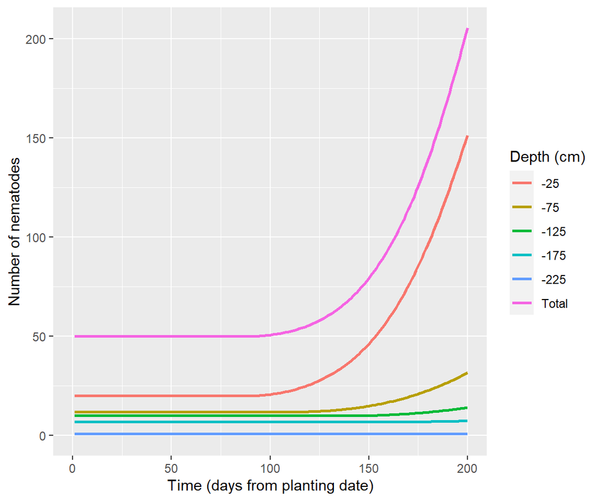

```r
plot_PopNem <- function(PopNem, total=FALSE, line_width=1){
  # function that plot the nematode population for each soil layer
  # input : PopNem , a df containing one colunm for each soil layer
  # output : ggplot graph, if total is True, add a col. with total pop.

  if(total){
    PopNem["Total"] <- rowSums(PopNem, na.rm = T)
  }

  # add a vector time to reshape/melt the DF
  time <- data.frame("time"= c(1:nrow(PopNem)))
  PopNem_time <- cbind(time, PopNem)

  # melt in 3 columns
  PopNem_long <- melt(PopNem_time, id="time", variable.name = "depth" )

  # plot
  PopNem_plot <- ggplot(PopNem_long,
                     aes(x = time,
                         y = value,
                         color = depth)) +  geom_line(size=line_width) +
    labs(y="Number of nematodes", x="Time (days from planting date)", color="Depth (cm)")+
    expand_limits(x = 0, y = 0)

  # return the plot
  return(PopNem_plot)
}

# test
PopNem <- Nematode_population(RV, modele, PopNem_init = c(20, 12, 10, 7, 1),  alpha = 0.015,
                              planting_day = 90, seuil = 11, K_pot=500, r_max = 0.07)

plot_PopNem(PopNem, T)
```

### All from the beginning

```r
# launch simulation
current_rootsystem <- launch_simulation(simulation_time = 200)

# root volume
RV <- root_volume(current_rootsystem, 200, 50)

print(paste("You should have", ncol(RV), "value of initial population !"))
```

```
[1] "You should have 4 value of initial population !"
```

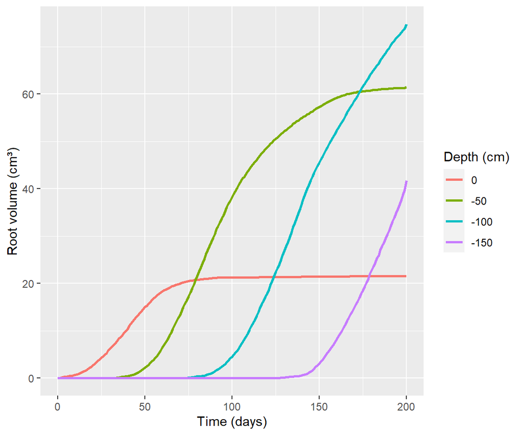

```r
# initial population of nematode in each layer of soil
PopNem_init = c(10, 8, 7, 5)

# model the nem. population
PopNem <- Nematode_population(RV, modele, PopNem_init,  alpha = 0.015, planting_day = 90,
                              seuil = 11, K_pot=500, r_max = 0.07)

# plot Root and Nem
plot_RV(RV)
```

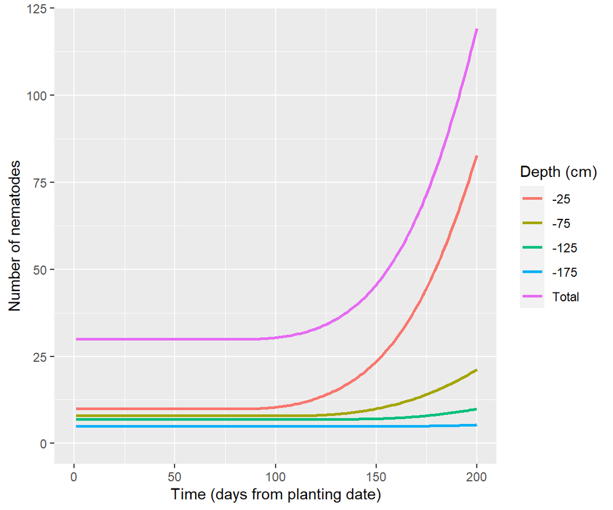

```r
plot_PopNem(PopNem, T)
```

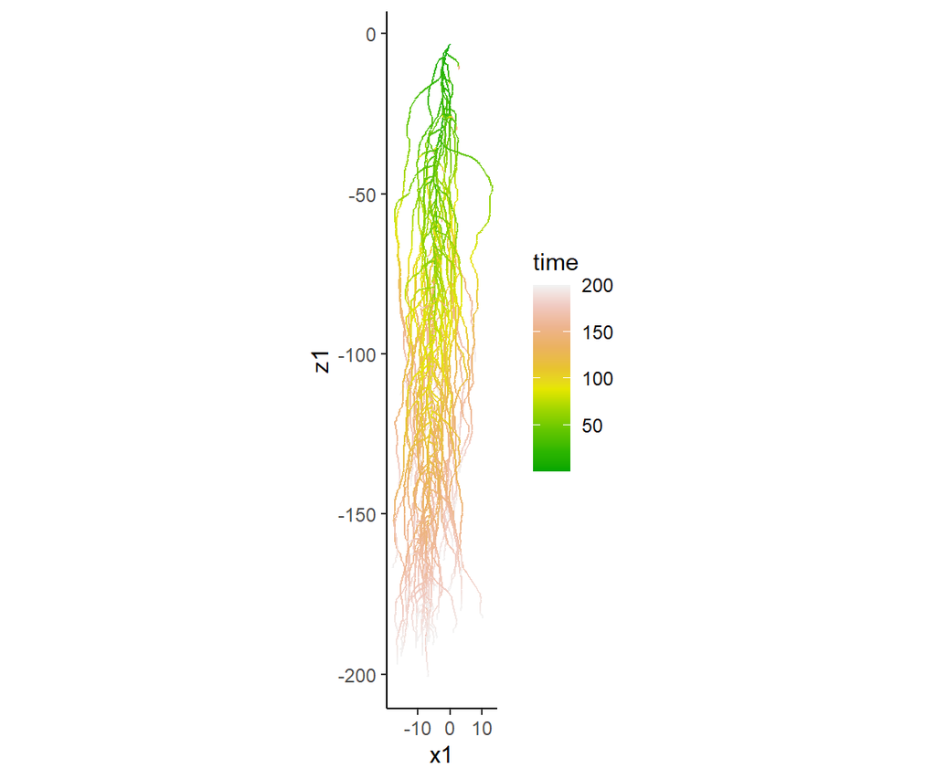

```r
plot_current_root_S(current_rootsystem)
```

# 8. CHANGING THE ROOT ARCHITECTURE TO SEE THE INFLUENCE ON NEMATODE

In this section we decided to see the effect of `ln_1` (the lateral density on the taproot) and `lmax_3` (the maximum length of the long-lateral roots) on the nematode population. We will change their value in a certain range separately and then together.

First we define another function to make our calculation easier :

## Function simulation_2

```r
launch_simulation2 <- function(simulation_time = 200, ln_1 = 1.6, lmax_3 =  240){
  ## function to launch the simulation (only changing relevant param):
  ## 1. store parameter defined in the global env. in the P and R param file
  ## 2. run CRootBox
  ## 3. return the current rootsystem as a dataframe

 # Parameters relevant for that simulation
 pparam$val1[pparam$param == "simtime"] <- simulation_time
 rparam$val1[rparam$name == "Taproot" & rparam$param == "ln"] <-  ln_1
 rparam$val1[rparam$name == "LongLateral" & rparam$param == "lmax"] <- lmax_3

 # update the input text files
 write_rparam(rparam, "inputs/param.rparam")
 write_pparam(pparam, "inputs/param.pparam")

 ### Run crootbox ###
 system("inputs/crootbox.exe") # Run crootbox for windows

 # Load the simulated data into R to process it and to store it for further use
 current_rootsystem <- fread("outputs/current_rootsystem.txt", header = T)

 return(current_rootsystem)
}
```

## Changing `ln_1` parameter only

```r
# Define param values
ln1_vec <-  c( 1 , 1.6 ,  3.1 ,  4.6 )
lmax_3 <- 170

# empty df for storing results
Nematode_df <- setNames(data.frame(matrix(ncol = 1, nrow = simulation_time)), 'Time')
Nematode_df['Time'] <- c(1:simulation_time)

final_pop <- NULL
all_rootsystems <- NULL
all_totlength <- NULL
n_tot_simulation <- length(ln1_vec)
n_cr_sim <- 0
n_rep <- 10

# initial population of nematode in each layer of soil
PopNem_init = c(20, 12, 10, 7, 1) # approx 50 nematodes in the beginning ~(Werf et al., 1986)

### loop over param ###
for (ln_1 in ln1_vec){
  # Output the advancement in the simulation
  n_cr_sim <- n_cr_sim + 1

  for(i in c(1:n_rep)){
    print(paste0(n_cr_sim, " / ", n_tot_simulation, " crootbox sims || Rep - ", i))

    # assign new value to the param & run
    current_rootsystem <- launch_simulation2(ln_1 = ln_1, lmax_3 = lmax_3)

    # root volume
    RV <- root_volume(current_rootsystem, 250, 50)

    # model the nem. population
    PopNem <- Nematode_population(RV, modele, PopNem_init,  alpha = 0.015, planting_day = 90,
                                  seuil = 11, K_pot=500, r_max = 0.07)
    # Store total population
    Nematode_df[, "total_pop"] <-rowSums(PopNem, na.rm = T)

    final_pop <- rbind(final_pop, Nematode_df[simulation_time,]%>%
                                    mutate(ln_1 = ln_1, lmax_3 = lmax_3)
                       )
  }

  #####
      # We enrich the root system simulation data with metadata
      current_rootsystem <- current_rootsystem %>%
                            mutate(ln_1 = ln_1, lmax_3 = lmax_3)

      # We create a table with all the root systems
      all_rootsystems <- rbind(all_rootsystems, current_rootsystem)

      # # We store the root system simulation with a unique name
      # write_csv(current_rootsystem,
      #           paste0("outputs/rootsystems/rootsystem_",vp,
      #                  "_",vs,
      #                  "_",ln,
      #                  ".csv"))

      # extract the root length density from the simulation data
      totlength <- data.frame(ln_1 = ln_1, lmax_3 = lmax_3,
                              simulation_id = n_cr_sim,
                              total_length = sum(current_rootsystem$length),
                              n_root = length(unique(current_rootsystem$branchID)))

      # We store in a data frame the rld from all the simulations
      all_totlength <- rbind(all_totlength, totlength)
  ###

}
```

```
[1] "1 / 4 crootbox sims || Rep - 1"
[1] "1 / 4 crootbox sims || Rep - 2"
[1] "1 / 4 crootbox sims || Rep - 3"
[1] "1 / 4 crootbox sims || Rep - 4"
[1] "1 / 4 crootbox sims || Rep - 5"
[1] "1 / 4 crootbox sims || Rep - 6"
[1] "1 / 4 crootbox sims || Rep - 7"
[1] "1 / 4 crootbox sims || Rep - 8"
[1] "1 / 4 crootbox sims || Rep - 9"
[1] "1 / 4 crootbox sims || Rep - 10"
[1] "2 / 4 crootbox sims || Rep - 1"
[1] "2 / 4 crootbox sims || Rep - 2"
[1] "2 / 4 crootbox sims || Rep - 3"
[1] "2 / 4 crootbox sims || Rep - 4"
[1] "2 / 4 crootbox sims || Rep - 5"
```

[output cut: 25 more lines]

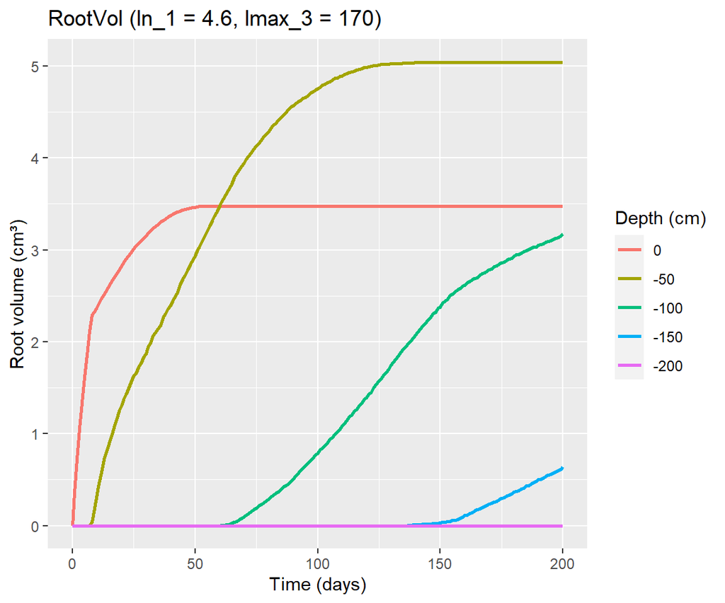

```r
  # plot Root and Nem
  print( plot_RV(RV)+
           ggtitle(paste0('RootVol (ln_1 = ',ln_1, ', lmax_3 = ',lmax_3,')'))  )
```

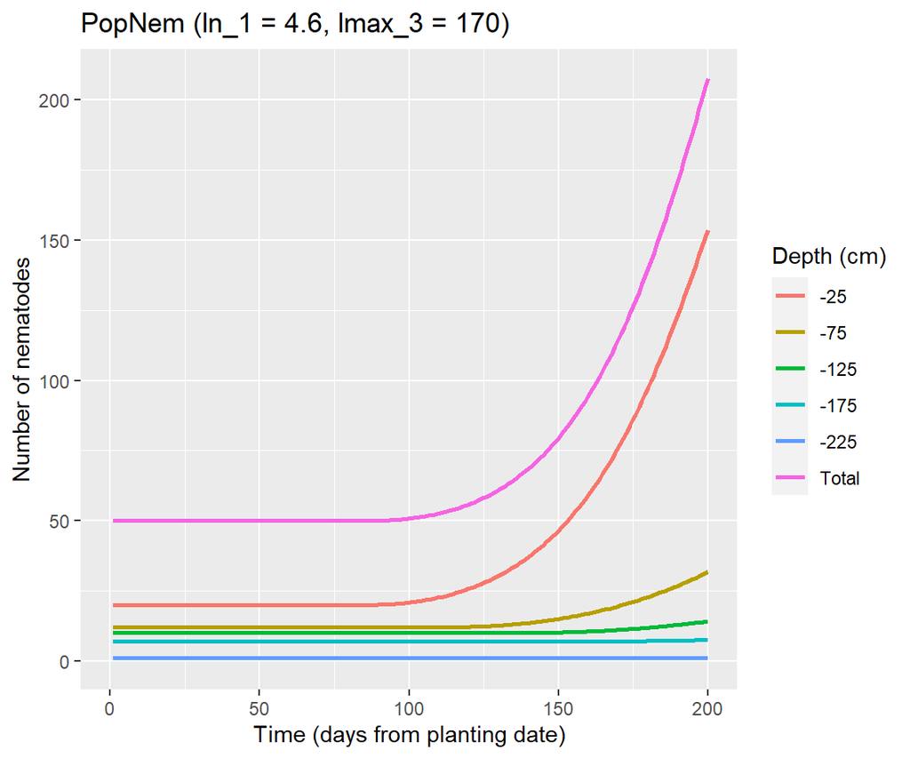

```r
  print( plot_PopNem(PopNem, T) +
           ggtitle(paste0('PopNem (ln_1 = ',ln_1, ', lmax_3 = ',lmax_3,')')) )
```

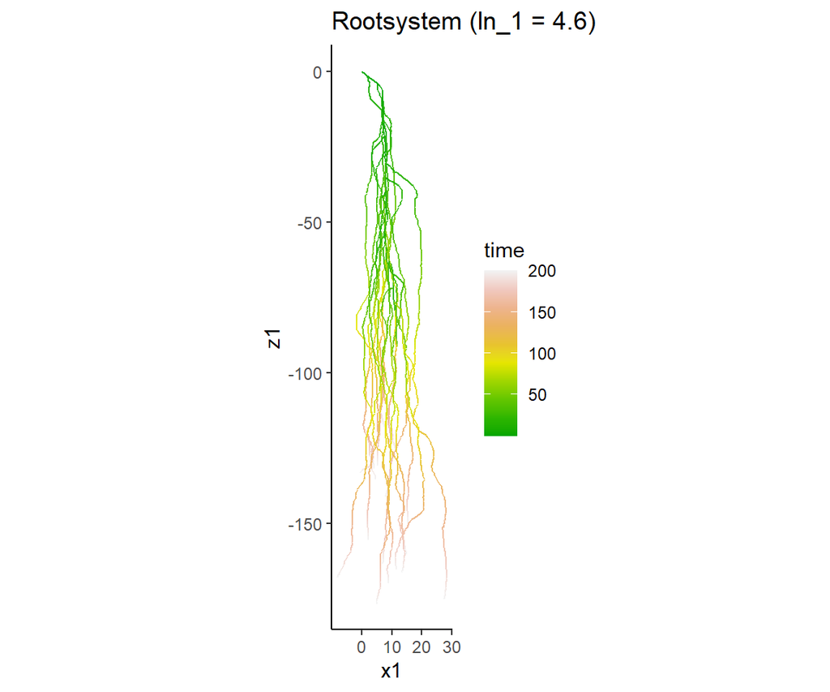

```r
  print( plot_current_root_S(current_rootsystem) +
           ggtitle(paste0('Rootsystem (ln_1 = ',ln_1, ')') ) )
```

### Compare the rootsystem

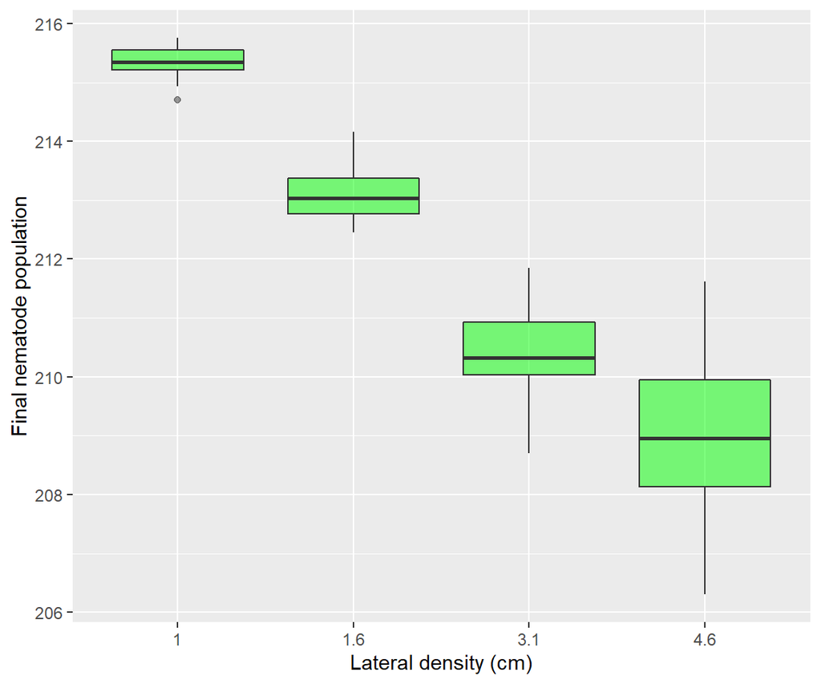

```r
# final result :
final_pop$ln_1 <- as.factor(final_pop$ln_1)

### boxplot
ggplot(final_pop, aes(x=ln_1, y=total_pop) ) +
  geom_boxplot( fill="green", alpha=0.5)+
  ylab("Final nematode population")+ xlab("Lateral density (cm)")
```

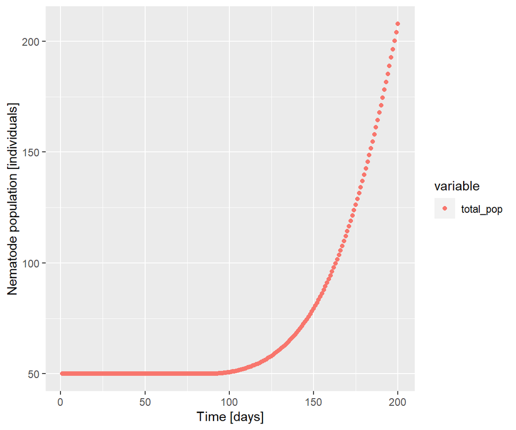

```r
# Everything on the same plot
df <- melt(Nematode_df, id.vars="Time")
ggplot(df, aes(Time,value, col=variable)) + geom_point() +
        ylab("Nematode population [individuals]") + xlab("Time [days]")
```

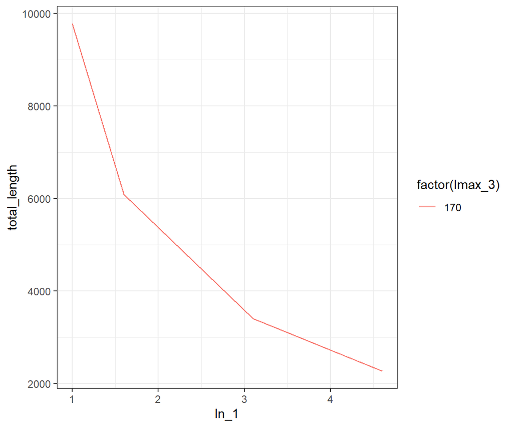

```r
all_totlength %>%
  ggplot(aes(ln_1, total_length,
             colour = factor(lmax_3))) +
  geom_line() +
  theme_bw()
```

## Changing `lmax_3` parameter only

```r
# Define param values
lmax3_vec <- c( 30 , 90 , 170 , 250)
ln_1 <- 1.6

# empty df for storing results
Nematode_df <- setNames(data.frame(matrix(ncol = 1, nrow = simulation_time)), 'Time')
Nematode_df['Time'] <- c(1:simulation_time)

final_pop <- NULL
all_rootsystems <- NULL
all_totlength <- NULL
n_tot_simulation <- length(lmax3_vec) # * length(ln1_vec)
n_cr_sim <- 0
n_rep <- 10

# initial population of nematode in each layer of soil
PopNem_init = c(20, 12, 10, 7, 1) # approx 50 nematodes in the beginning ~(Werf et al., 1986)

### loop over param ###
for (lmax_3 in lmax3_vec){
      # Output the advancement in the simulation
      n_cr_sim <- n_cr_sim + 1

  for(i in c(1:n_rep)){
    print(paste0(n_cr_sim, " / ", n_tot_simulation, " crootbox sims || Rep - ", i))

    # assign new value to the param & run
    current_rootsystem <- launch_simulation2(lmax_3 = lmax_3, ln_1 = ln_1)

    # root volume
    RV <- root_volume(current_rootsystem, 250, 50)

    # model the nem. population
    PopNem <- Nematode_population(RV, modele, PopNem_init,  alpha = 0.015, planting_day = 90,
                                  seuil = 11, K_pot=500, r_max = 0.07)
    # Store total population
    Nematode_df[, "total_pop"] <-rowSums(PopNem, na.rm = T)

    final_pop <- rbind(final_pop, Nematode_df[simulation_time,]%>%
                                    mutate(ln_1 = ln_1, lmax_3 = lmax_3)
                       )
  }

  #####
      # We enrich the root system simulation data with metadata
      current_rootsystem <- current_rootsystem %>%
                            mutate(ln_1 = ln_1, lmax_3 = lmax_3)

      # We create a table with all the root systems
      all_rootsystems <- rbind(all_rootsystems, current_rootsystem)

      # # We store the root system simulation with a unique name
      # write_csv(current_rootsystem,
      #           paste0("outputs/rootsystems/rootsystem_",vp,
      #                  "_",vs,
      #                  "_",ln,
      #                  ".csv"))

      # extract the root length density from the simulation data
      totlength <- data.frame(ln_1 = ln_1, lmax_3 = lmax_3,
                              simulation_id = n_cr_sim,
                              total_length = sum(current_rootsystem$length),
                              n_root = length(unique(current_rootsystem$branchID)))

      # We store in a data frame the rld from all the simulations
      all_totlength <- rbind(all_totlength, totlength)
  ###
}
```

```
[1] "1 / 4 crootbox sims || Rep - 1"
[1] "1 / 4 crootbox sims || Rep - 2"
[1] "1 / 4 crootbox sims || Rep - 3"
[1] "1 / 4 crootbox sims || Rep - 4"
[1] "1 / 4 crootbox sims || Rep - 5"
[1] "1 / 4 crootbox sims || Rep - 6"
[1] "1 / 4 crootbox sims || Rep - 7"
[1] "1 / 4 crootbox sims || Rep - 8"
[1] "1 / 4 crootbox sims || Rep - 9"
[1] "1 / 4 crootbox sims || Rep - 10"
[1] "2 / 4 crootbox sims || Rep - 1"
[1] "2 / 4 crootbox sims || Rep - 2"
[1] "2 / 4 crootbox sims || Rep - 3"
[1] "2 / 4 crootbox sims || Rep - 4"
[1] "2 / 4 crootbox sims || Rep - 5"
```

[output cut: 25 more lines]

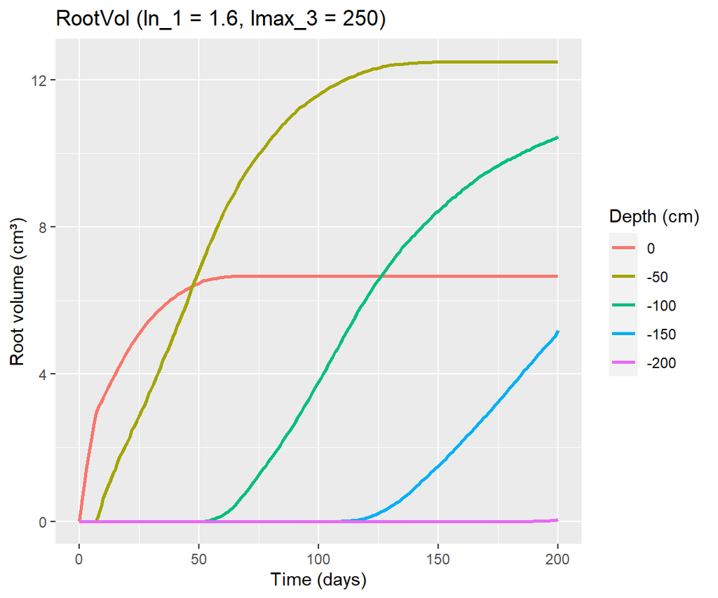

```r
  # plot Root and Nem
  print( plot_RV(RV)+
           ggtitle(paste0('RootVol (ln_1 = ',ln_1, ', lmax_3 = ',lmax_3,')'))  )
```

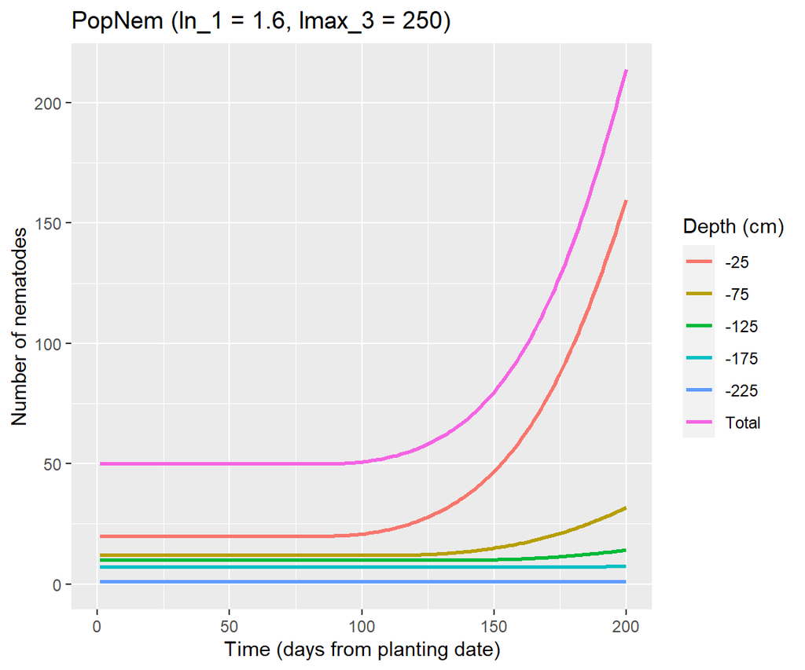

```r
  print( plot_PopNem(PopNem, T) +
           ggtitle(paste0('PopNem (ln_1 = ',ln_1, ', lmax_3 = ',lmax_3,')')) )
```

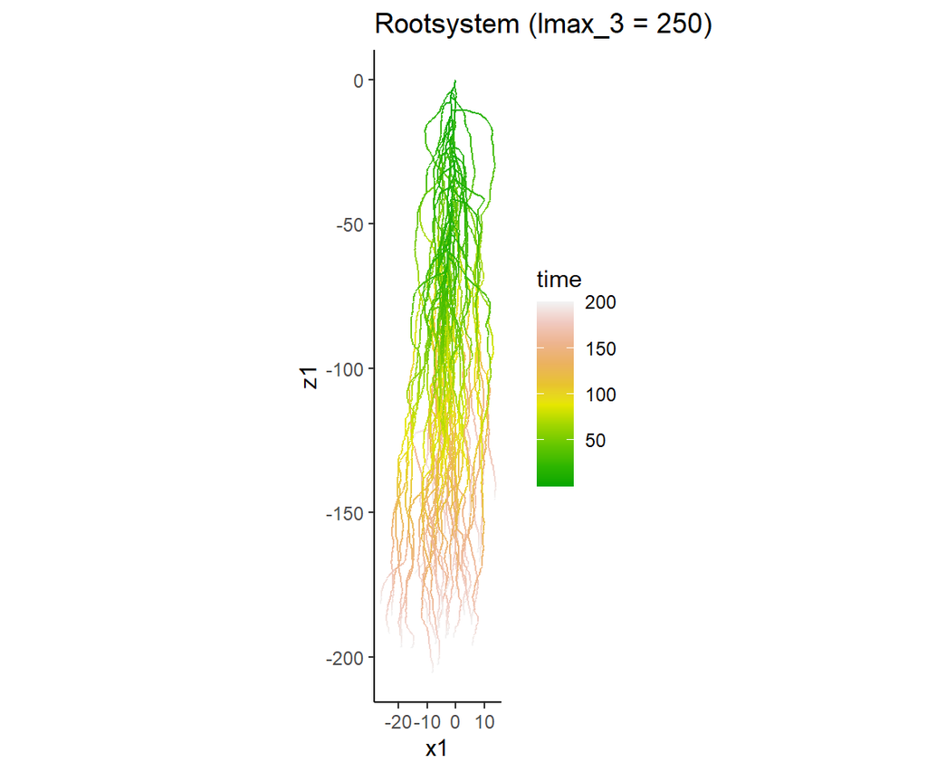

```r
  print( plot_current_root_S(current_rootsystem) +
           ggtitle(paste0('Rootsystem (lmax_3 = ',lmax_3, ')') ) )
```

### Compare the rootsystem

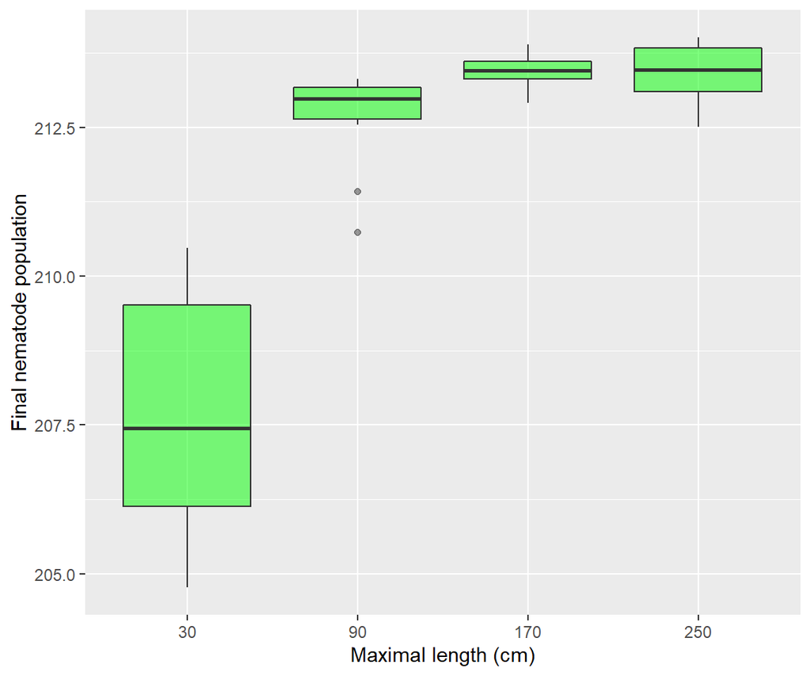

```r
# final result :
final_pop$lmax_3 <- as.factor(final_pop$lmax_3)

### boxplot
ggplot(final_pop, aes(x=lmax_3, y=total_pop) ) +
  geom_boxplot( fill="green", alpha=0.5)+
  ylab("Final nematode population") + xlab("Maximal length (cm)")
```

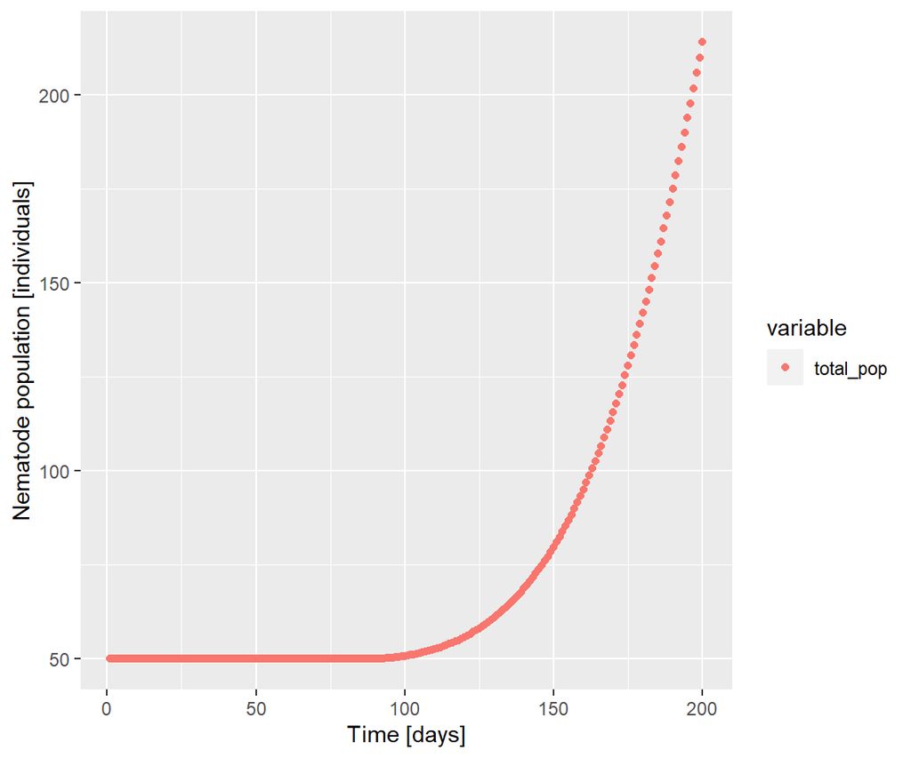

```r
# Everything on the same plot
df <- melt(Nematode_df, id.vars="Time")
ggplot(df, aes(Time,value, col=variable)) + geom_point() +
        ylab("Nematode population [individuals]") + xlab("Time [days]")
```

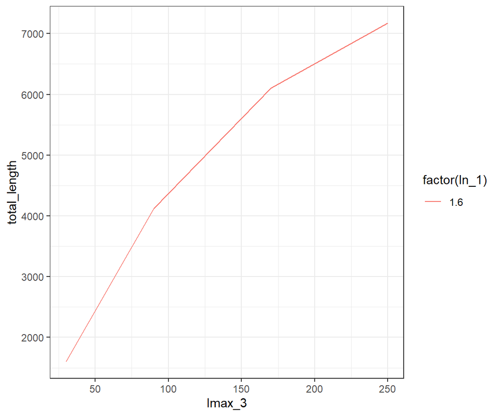

```r
all_totlength %>%
  ggplot(aes(lmax_3, total_length,
             colour = factor(ln_1))) +
  geom_line() +
  theme_bw()
```

## Changing both `ln_1` and `lmax_3`

```r
# Define param values
lmax3_vec <- c( 30 , 90 , 170 , 250)
ln1_vec <-  c( 1 , 1.6 ,  3.1 ,  4.6 )

# empty df for storing results
Nematode_df <- setNames(data.frame(matrix(ncol = 1, nrow = simulation_time)), 'Time')
Nematode_df['Time'] <- c(1:simulation_time)

final_pop <- NULL
all_rootsystems <- NULL
all_totlength <- NULL
n_tot_simulation <- length(lmax3_vec)  * length(ln1_vec)
n_cr_sim <- 0
n_rep <- 10

# initial population of nematode in each layer of soil
PopNem_init = c(20, 12, 10, 7, 1) # approx 50 nematodes in the beginning ~(Werf et al., 1986)

### loop over param ###
for (ln_1 in ln1_vec){
  for (lmax_3 in lmax3_vec){
    # Output the advancement in the simulation
    n_cr_sim <- n_cr_sim + 1
    print(paste0(n_cr_sim, " / ", n_tot_simulation, " crootbox sims :"))

    for(i in c(1:n_rep)){
      print(paste0("                  || Rep - ", i))

      # assign new value to the param & run
      current_rootsystem <- launch_simulation2(lmax_3 = lmax_3, ln_1 = ln_1)

      # root volume
      RV <- root_volume(current_rootsystem, 250, 50)

      # model the nem. population
      PopNem <- Nematode_population(RV, modele, PopNem_init,  alpha = 0.015, planting_day = 90,
                                    seuil = 11, K_pot=500, r_max = 0.07)
      # Store total population
      Nematode_df[, "total_pop"] <-rowSums(PopNem, na.rm = T)

      final_pop <- rbind(final_pop, Nematode_df[simulation_time,]%>%
                                      mutate(ln_1 = ln_1, lmax_3 = lmax_3)
                         )
    }

    #####
        # We enrich the root system simulation data with metadata
        current_rootsystem <- current_rootsystem %>%
                              mutate(ln_1 = ln_1, lmax_3 = lmax_3)

        # We create a table with all the root systems
        all_rootsystems <- rbind(all_rootsystems, current_rootsystem)

        # # We store the root system simulation with a unique name
        # write_csv(current_rootsystem,
        #           paste0("outputs/rootsystems/rootsystem_",vp,
        #                  "_",vs,
        #                  "_",ln,
        #                  ".csv"))

        # extract the root length density from the simulation data
        totlength <- data.frame(ln_1 = ln_1, lmax_3 = lmax_3,
                                simulation_id = n_cr_sim,
                                total_length = sum(current_rootsystem$length),
                                n_root = length(unique(current_rootsystem$branchID)))

        # We store in a data frame the rld from all the simulations
        all_totlength <- rbind(all_totlength, totlength)
    ###

    # plot Root and Nem
    # print( plot_RV(RV)+
    #          ggtitle(paste0('RootVol (ln_1 = ',ln_1, ', lmax_3 = ',lmax_3,')'))  )
    # print( plot_PopNem(PopNem, T) +
    #          ggtitle(paste0('PopNem (ln_1 = ',ln_1, ', lmax_3 = ',lmax_3,')')) )
    # print( plot_current_root_S(current_rootsystem) +
    #          ggtitle(paste0('Rootsystem (ln_1 = ',ln_1, ')') ) )
  }
}
```

```
[1] "1 / 16 crootbox sims :"
[1] "                  || Rep - 1"
[1] "                  || Rep - 2"
[1] "                  || Rep - 3"
[1] "                  || Rep - 4"
[1] "                  || Rep - 5"
[1] "                  || Rep - 6"
[1] "                  || Rep - 7"
[1] "                  || Rep - 8"
[1] "                  || Rep - 9"
[1] "                  || Rep - 10"
[1] "2 / 16 crootbox sims :"
[1] "                  || Rep - 1"
[1] "                  || Rep - 2"
[1] "                  || Rep - 3"
```

[output cut: 161 more lines]

```r
#### End loop
```

### Compare the rootsystem

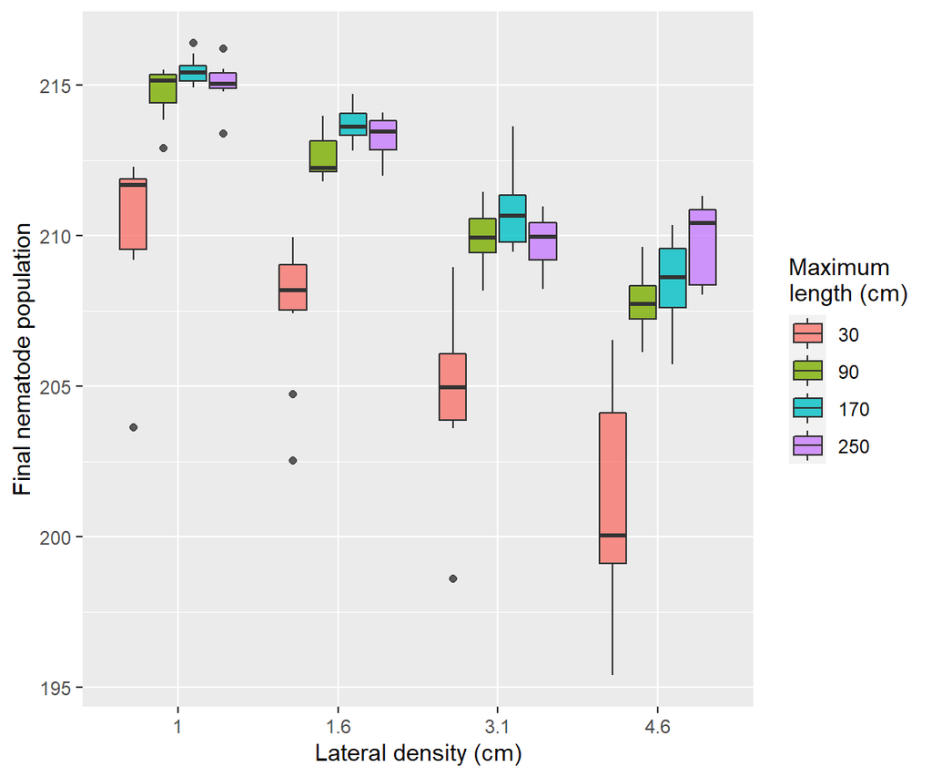

```r
# final result :
final_pop$lmax_3 <- as.factor(final_pop$lmax_3)
final_pop$ln_1 <- as.factor(final_pop$ln_1)

### boxplot
ggplot(final_pop, aes(fill=lmax_3, y=total_pop, x=ln_1 ) ) +
  geom_boxplot(alpha=0.8)+
  ylab("Final nematode population") + xlab("Lateral density (cm)") +
  labs(fill="Maximum \nlength (cm)")
```

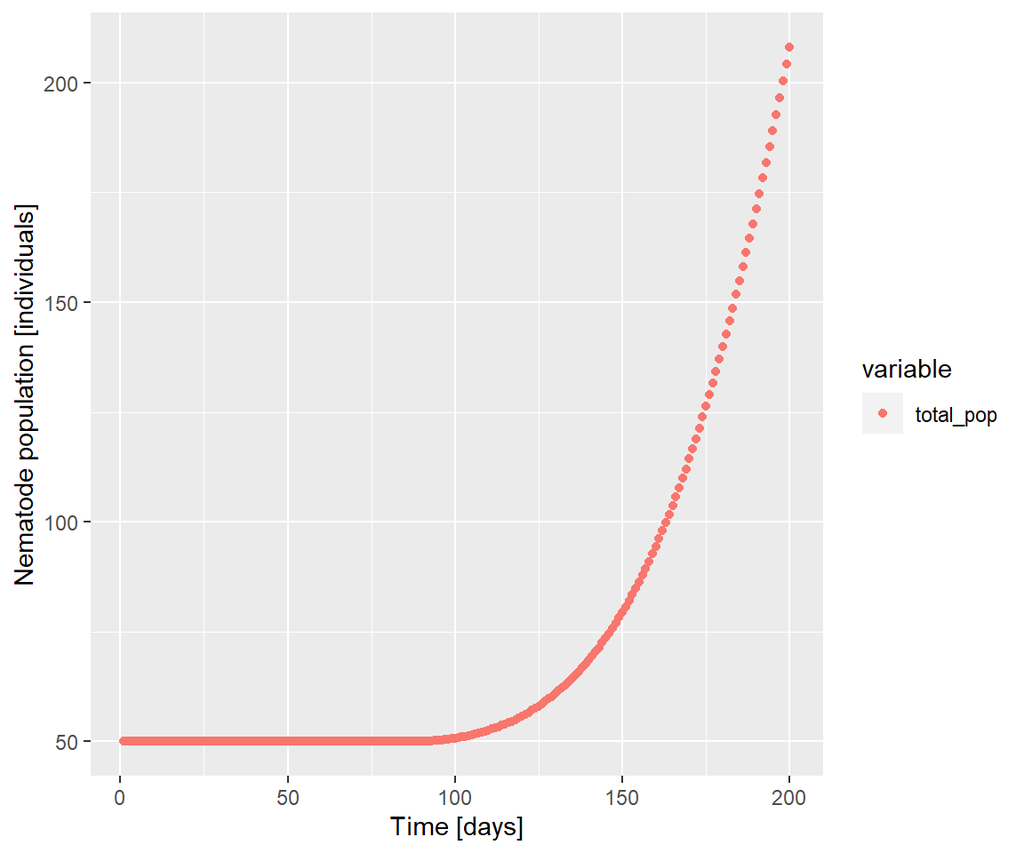

```r
# Everything on the same plot
df <- melt(Nematode_df, id.vars="Time")
ggplot(df, aes(Time,value, col=variable)) + geom_point() +
        ylab("Nematode population [individuals]") + xlab("Time [days]")
```

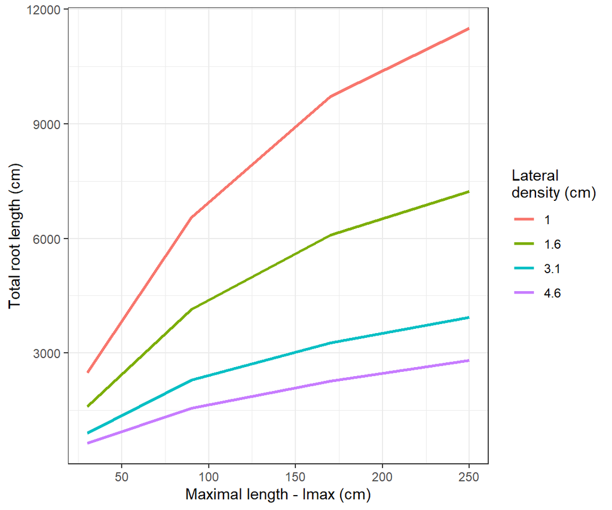

```r
all_totlength %>%
  ggplot(aes(lmax_3, total_length,
             colour = factor(ln_1))) +
  geom_line(size=1) + ylab("Total root length (cm)") + xlab("Maximal length - lmax (cm)")+
  labs(colour= "Lateral \ndensity (cm)")+
  theme_bw()
```

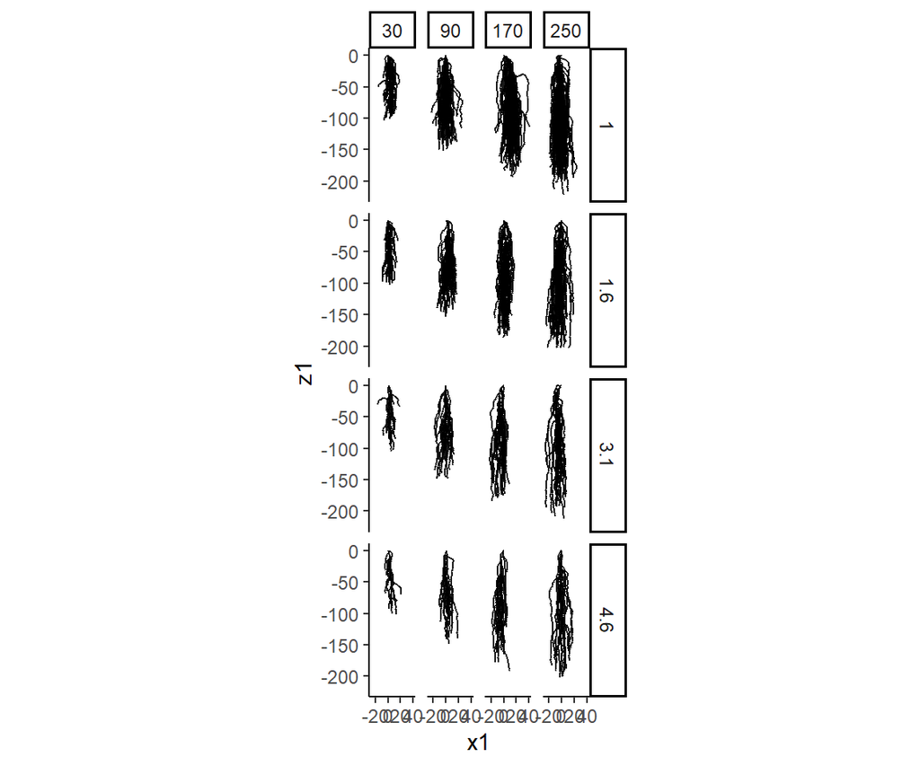

```r
# Root system
all_rootsystems %>%
  ggplot() +
  theme_classic() +
  geom_segment(aes(x = x1, y = z1, xend = x2, yend = z2), alpha=0.9) +
  coord_fixed() +
  facet_grid(ln_1 ~ lmax_3)
```